# STA 138 - Final Project - 2019 FALL

Hao Luo, 912423597

# INTRODUCTION

Byssinosis is a form of occupational disease, it also know as brown lung disease. According to **Healthline.com**, it is often caused by inhaling particles from flax, hemp or cotton. The symptoms of byssinosis are similar to asthma and include tightness in the chest, wheezing, and coughing. In worst case senario, subject may experience flu-like symptons. Therefore, we want to investigate relationshops between the disease and the factors of smkoing status, sex, race, length of employment, and workspace.

In this investigation, wether a person has byssinosis or not, is a categorical variable and it only has two levels, and the explanatory variables are either nominal or binary (see the table at **EXPLANATORY VARIABLES** below). Furthermore, suppose that eash subject in this investigation is independent and notice that the probability of someone getting Byssinosis is $\frac{165}{5419} \approx 3.04\%$, then the response variable is distributed Bernoulli

First, we will conduct an exploratory data analysis to check the integrity of our dataset and the relationship between the explanatory and response variables. Then, we will use Backward selection method based on the Akaike Information Criterion (AIC) to select the best model. Then, removing influential outliers from our dataset based on the p-values of standardized residuals and the DFBeta plot. Finally, we want a model that can predict the probability that wether a person gets Byssinosis reasonably well.

# EXPLORATORY ANAlYSIS ON DATASET

An exploratory data analysis is carried out on the given data set to determine the integrity of our dataset.

## EXPANATORY VARIABLES

```
##   Employment Smoking Sex Race Workspace Bys
## 1        <10     Yes   M    W         1   0
## 2        <10     Yes   M    W         1   0
## 3        <10     Yes   M    W         1   0
## 4        <10     Yes   M    W         1   0
## 5        <10     Yes   M    W         1   0
```

### Employment

An ordinal variable that split the years working in the industry into three groups **<10**, **10-19**, and **>=20**. Majority of the subjects had been in the industry less than 10 years.

| years | <10 | 10-19 | >=20 |
| --- | --- | --- | --- |
| counts | 2729 | 712 | 1978 |

### Smoking

A catagorical variable with two levels of **yes**, or **NO**. the smoking status on a subject wether they are currently smoking or not smoking in the last 5 years. We can see that 58.85% of the subjects which is the majority of the workers that who are smokers.

| Smoking | No | Yes |
| --- | --- | --- |
| counts | 2230 | 3189 |

### Sex

A catagorical variables indicates **Female** or **Male**. The proportion of the gender is 2916/(2503+2916) = 53.81%, which male is slightly higher by 3.81%. A

| Gender | F | M |
| --- | --- | --- |
| counts | 2503 | 2916 |

### Race

A catagorical variable indicates the race **White** or **Other**. The majority of the workers are white. Race sometimes plays a role on certain diseases.

| Race | Other | White |
| --- | --- | --- |
| counts | 1903 | 3516 |

### Workspace

A catagorical variable with levels of thee: **[1,(most dusty)]**, **[2,(less dusty)]**, and **[3,(least dusty)]**.

| Workspace | [1,(most dusty)] | [2,(less dusty)] | [3,(least dusty)] |
| --- | --- | --- | --- |
| counts | 669 | 1300 | 3450 |

## RESPONSE VARIABLE

### Byssinosis and Employment

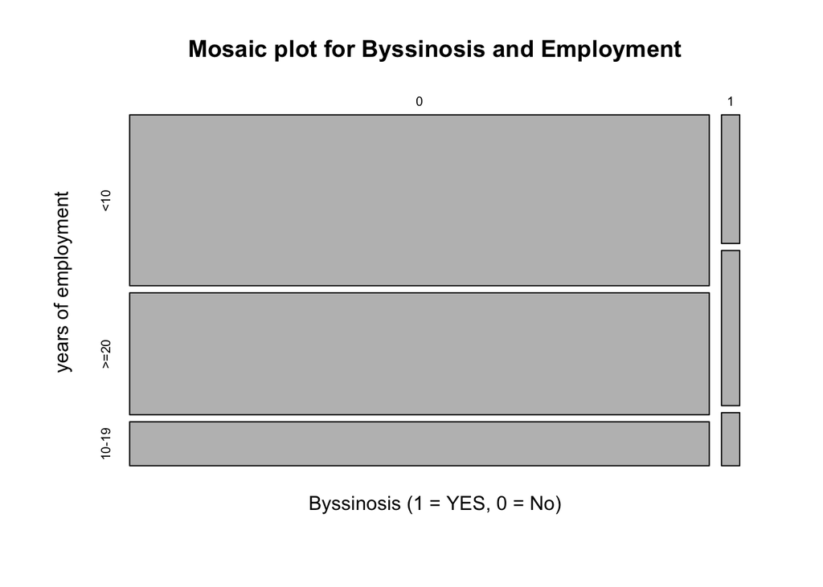

### Byssinosis and Smoking

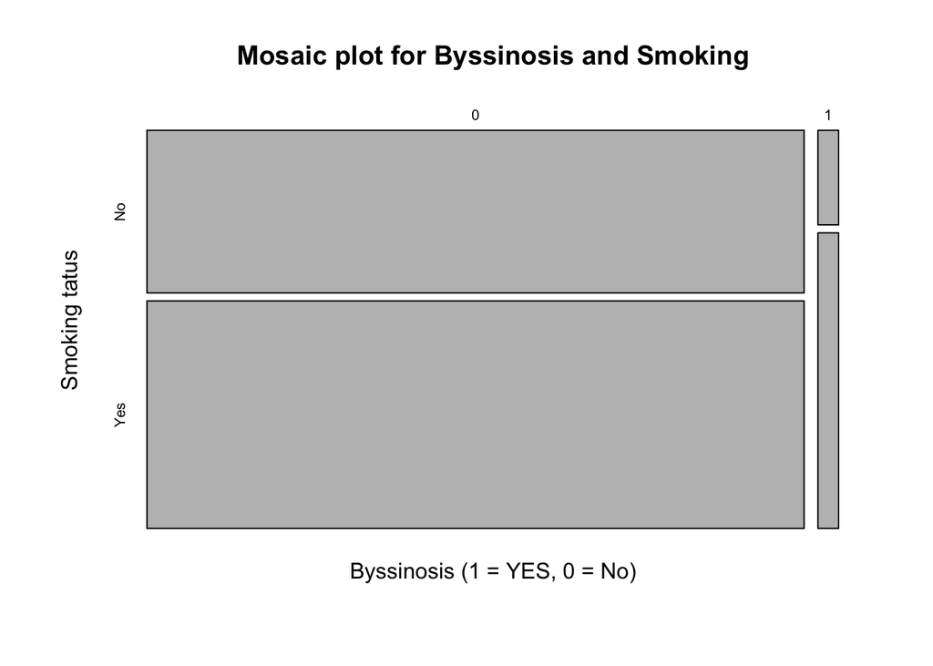

### Byssinosis and Sex

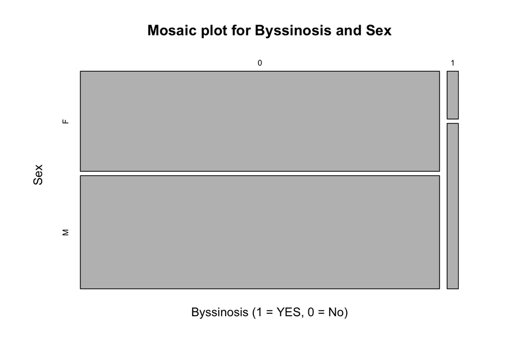

### Byssinosis and Race

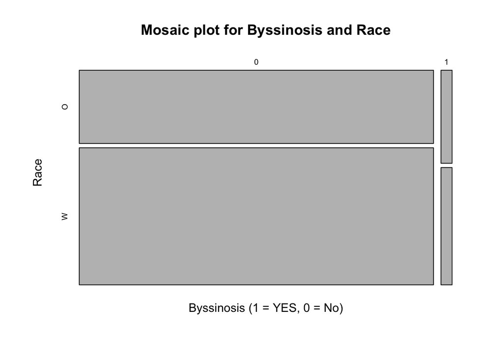

### Byssinosis and Workspcace

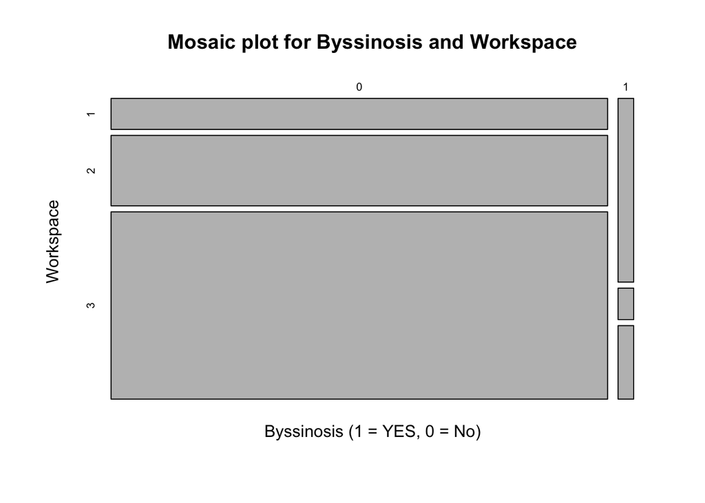

## MODEL SELECTION

### Method

For this investivation, our goal is to predict the chance of someone getting byssinosis based on our variables. Therefore, our main focous is not on making inferences of our logistic regression model. Thus being able to predict the probability of the occurrence of bissinosis is more important than getting a “best” model. With having this mind, we will use the backward selection with the Akaike Information Criterion (AIC) in the model selection process.

The reason for using backward selection method and AIC is that they both thend to over-fit the data. Benefit in doing so will provide us a better prediction on such disease.

We conducted the backward model selection process with AIC in R. The package we used for this procedure is the built-in {stats} package in R. Specifically, we used the step function. Here are the coefficients of the best model and the backward selection process:

Logit($\pi$) = -2.4546 + 0.6728 $X_{Employment >= 20}$ + 0.5060 $X_{Employment 10-19}$ + 0.6210 $X_{Smoking, Yes}$ - 2.5493 $X_{Workspace, 2}$ - 2.7175 $X_{Workspace, 3}$

```
## Start:  AIC=1213.94
## Bys ~ Employment + Smoking + Sex + Race + Workspace
##
##              Df Deviance    AIC
## - Sex         1   1198.2 1212.2
## - Race        1   1198.2 1212.2
## <none>            1197.9 1213.9
## - Employment  2   1210.8 1222.8
## - Smoking     1   1209.7 1223.7
## - Workspace   2   1396.6 1408.6
##
## Step:  AIC=1212.23
## Bys ~ Employment + Smoking + Race + Workspace
##
##              Df Deviance    AIC
## - Race        1   1198.5 1210.5
## <none>            1198.2 1212.2
## - Employment  2   1210.8 1220.8
## - Smoking     1   1209.7 1221.7
## - Workspace   2   1418.5 1428.5
##
## Step:  AIC=1210.55
## Bys ~ Employment + Smoking + Workspace
##
##              Df Deviance    AIC
## <none>            1198.5 1210.5
## - Smoking     1   1210.0 1220.0
## - Employment  2   1213.1 1221.1
## - Workspace   2   1445.6 1453.6
```

### Checking For Influential Outliers

#### Method

it is crucial to check if there is any point that does not follow our model. Outliers are found using the standardized residual method. In addition, the DFBeta of each sample is also calculated to see its influence. Only the influential outliers are removed.

#### Result

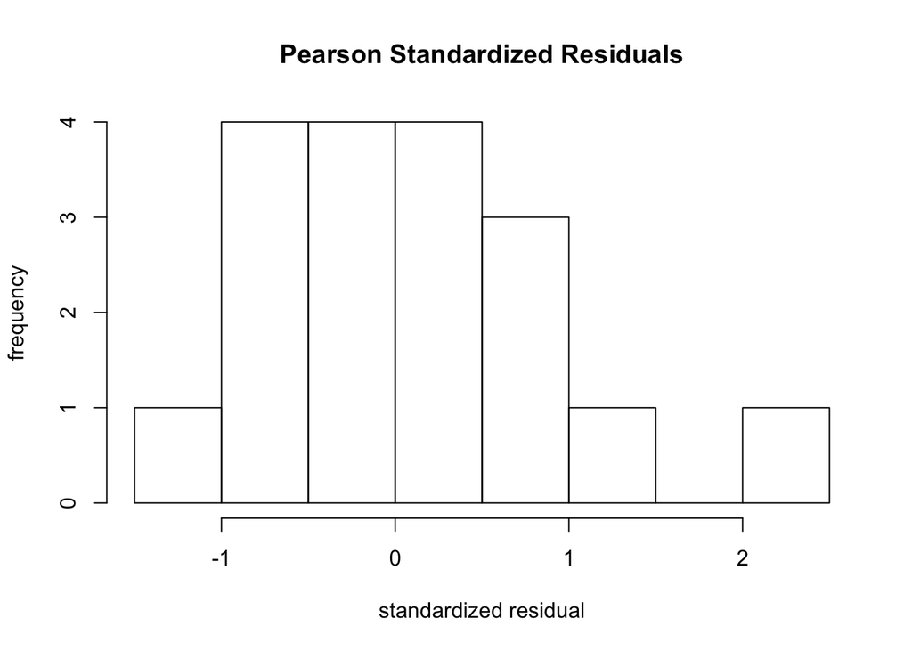

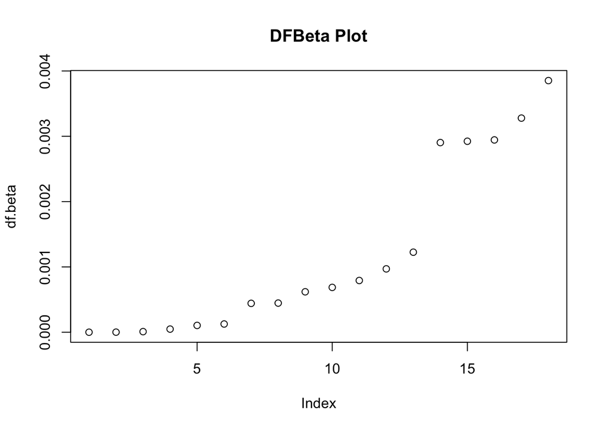

```
##    Employment Smoking Sex Race Workspace Bys
## 14        <10     Yes   M    W         1   0
```

After removing the outlier, we have a new logistic regression model which will be introduced later.

### Interaction Term

#### Model Selection

To study if the interaction terms may affect the goodness of the fit, we fitted all interactions between two variables to see if we should add interaction term to our model. See the chart below. By AIC, we have **Smoking*Workspace** as the interaction term. We do not know if the interaction term has effect to the model or not. Therefore, we will conduct a Likelihood Ratio test.

|  | LL | p | n | AIC | BIC |
| --- | --- | --- | --- | --- | --- |
| Bys ~ Employment + Smoking + Workspace | -599.125 | 6 | 5418 | 1210.250 | 1249.835 |
| Bys ~ Employment + Smoking + Workspace + Employment*Smoking | -598.233 | 8 | 5418 | 1212.465 | 1265.245 |
| Bys ~ Employment + Smoking + Workspace + Employment*Workspace | -596.844 | 10 | 5418 | 1213.689 | 1279.663 |
| Bys ~ Employment + Smoking + Workspace + Smoking*Workspace | -596.689 | 8 | 5418 | 1209.377 | 1262.157 |

#### Likelihood Ratio test

Therefore, our final model is:

ln($\frac{\hat \pi}{1-\hat \pi}$) = -2.7132 + 0.6614 $X_{Employment >= 20}$ + .4964 $X_{Employment 10-19}$ + 0.9595 $X_{Smoking, Yes}$ - 1.7767 $X_{Workspace, 2}$ - 2.3459 $X_{Workspace, 3}$ -1.1830 $X_{Smoking, Yes}*X_{Workspace, 2}$ - 0.4886 $X_{Smoking, Yes}*X_{Workspace, 3}$

### Interpretation of the Logistic Regression Model

Since the odds are much more meaningful than the log odds, we will exponentiate the model coefficients before interpret.

- $X_{Employment >= 20}$

  While holding other variables constant, the odds of getting Byssinosis for people who has been employed greater or equal 20 years is 1.937503 times of who has been emplyed less than ten years.
- $X_{Employment 10-19}$

#### Model Goodness of Fit Check with ROC Plot and Error Matrix

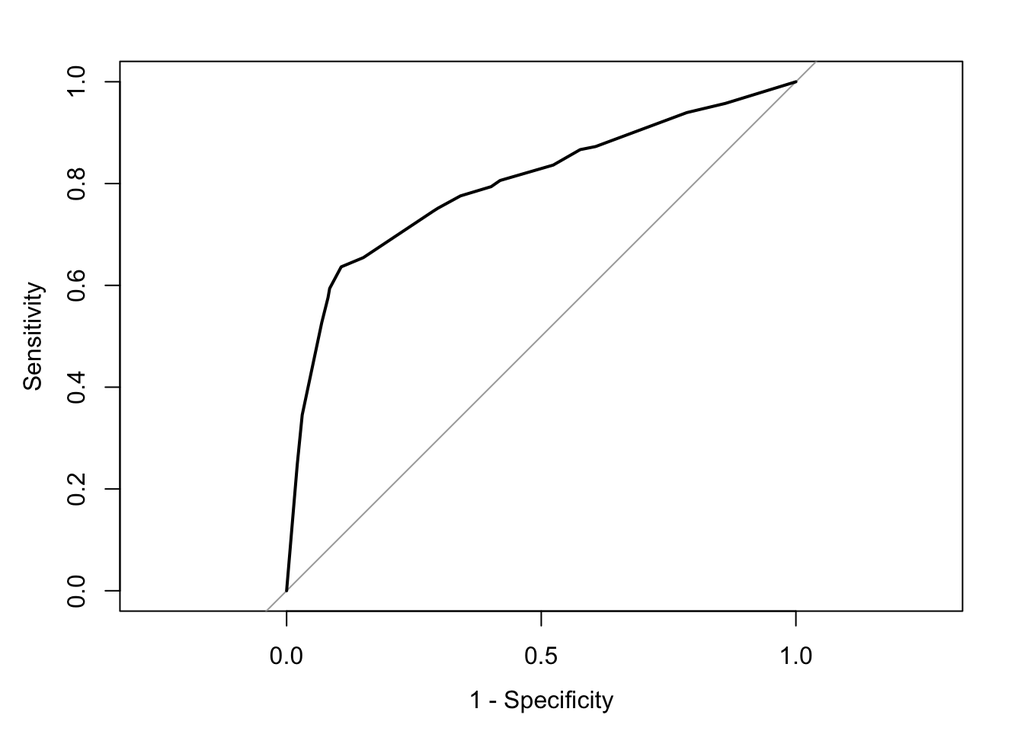

To check the overall Goodness of fit, refer to the ROC plot above. According to R, the AUC (area under the curve) is 0.7977 with 95% confidence interval (0.7564 , 0.839), it indicagtes that our model fits very good with to the data.

Furthermore, we chose $\pi_o$ = 0.0304 as a cutoff and built an error matrix in R. If $\hat \pi > 0.0304$, then it sugguest that the subject has byssinosis and vice versa. Please refer to the tables below.

| ERROR MATRIX | $\hat y = 0$ | $\hat y = 1$ | total |
| --- | --- | --- | --- |
| y = 0 | 4690 | 563 | 5253 |
| y = 1 | 60 | 105 | 165 |
| total | 4750 | 668 | 5418 |

| Sensitivity | Specificity | Error-Rate |
| --- | --- | --- |
| 0.6363636 | 0.8928231 | 0.1149871 |

The result is not bad for predicting who acturally has such disease. However, the sensitivity is a bit quite low for predicting diseases. Such a low Sensitivity might be due to the overffiting from the model, small data set. For what we have so far, it should be acceptable for disease prevention. For the model to be medical grade, we need more data.

## Application of the Logistic Model

Assume we want to predict the probability of Byssinosis for an individual who has been working in the industry for more than 20 years, smokes, and work in the most dusty envirment.

ln($\frac{\hat \pi}{1-\hat \pi}$) = -2.7132 + 0.6614 $X_{Employment >= 20}$ + 0.9595 $X_{Smoking, Yes}$

$\hat \pi_1$ = 0.2511854

Based on the model, the probability for such an indivual to have Byssinosis is approximately 25.12%

## Conclusion

```
##
## Call:
## glm(formula = Bys ~ Employment + Workspace + Smoking, family = binomial(link = "logit"),
##     data = new_df)
##
## Deviance Residuals:
##     Min       1Q   Median       3Q      Max
## -0.7385  -0.2023  -0.1486  -0.1450   3.2178
##
## Coefficients:
##                 Estimate Std. Error z value Pr(>|z|)
## (Intercept)      -2.4527     0.2047 -11.984  < 2e-16 ***
## Employment>=20    0.6706     0.1813   3.698 0.000217 ***
## Employment10-19   0.5036     0.2490   2.022 0.043129 *
## Workspace2       -2.5507     0.2614  -9.759  < 2e-16 ***
## Workspace3       -2.7188     0.1898 -14.322  < 2e-16 ***
## SmokingYes        0.6222     0.1908   3.262 0.001108 **
## ---
## Signif. codes:  0 '***' 0.001 '**' 0.01 '*' 0.05 '.' 0.1 ' ' 1
##
## (Dispersion parameter for binomial family taken to be 1)
##
##     Null deviance: 1477.1  on 5417  degrees of freedom
## Residual deviance: 1198.3  on 5412  degrees of freedom
## AIC: 1210.3
##
## Number of Fisher Scoring iterations: 7
```

Based on the p-value of each explanatory variable, the variable with the smallest p-value is less than 2e-16, which indicates that this variable has the significant effect on the response variable. Then followed by the workspaces that indicates the most important variable. Then, the rest of the variables are important because they are be low 0.05. Based on the variable, it could contribute a positive or negative effect on our response variable.

## R Appendix

```r
library(ggplot2)
library(LogisticDx)
library(pROC)

dat_bys = read.csv("Byssinosis.csv")

# begin ------funtion to reasemble the data frame for Byssinosis to be [yex,no] variable---------
dat_new_bys_yes = data.frame()
NEW_FRAME = function( dat = y, v = x) {
  a = dat[1,]
  for (i in (1: (length(v))) ){
    if ( v[i] != 0) {
      for ( j in (1: v[i] )){
        a = rbind(a, dat[i,])
      }
    }
  }
  a = a[-c(1),]
  return(a)
}

a = NEW_FRAME(dat = dat_bys, v = dat_bys$Non.Byssinosis)
b = NEW_FRAME(dat = dat_bys, v = dat_bys$Byssinosis)
#non-BYS
a = a[,1:5]
a$Bys = 0
#BYS
b = b[,1:5]
b$Bys = 1

#conbine Data frame
df = rbind(a,b)
df$Workspace = factor(df$Workspace)
row.names(df) = 1:nrow(df)
# -------------- End -------------------------------------------------
# begin ----------Expanatory--------------------------------
head(df,5)
#table(df$Employment)
#table(df$Smoking)
#table(df$Sex)
#table(df$Race)
#table(df$Workspace)
# ========== response variable ----------
mosaicplot(table(df$Bys, df$Employment),
           main = 'Mosaic plot for Byssinosis and Employment',
           xlab = "Byssinosis (1 = YES, 0 = No)",
           ylab = "years of employment")


mosaicplot(table(df$Bys, df$Smoking),
           main = 'Mosaic plot for Byssinosis and Smoking',
           xlab = "Byssinosis (1 = YES, 0 = No)",
           ylab = "Smoking tatus")

mosaicplot(table(df$Bys, df$Sex),
           main = 'Mosaic plot for Byssinosis and Sex',
           xlab = "Byssinosis (1 = YES, 0 = No)",
           ylab = "Sex")



mosaicplot(table(df$Bys, df$Race),
           main = 'Mosaic plot for Byssinosis and Race',
           xlab = "Byssinosis (1 = YES, 0 = No)",
           ylab = "Race")




mosaicplot(table(df$Bys, df$Workspace),
           main = 'Mosaic plot for Byssinosis and Workspace',
           xlab = "Byssinosis (1 = YES, 0 = No)",
           ylab = "Workspace")


# end---------explanatory variable----------
#---MODEL selection---

all_lm = glm( Bys ~ Employment + Smoking + Sex + Race + Workspace, family = binomial(link = logit), data = df)

empty_lm = glm(Bys ~ 1 , data = df, family = binomial(link = logit))

best_lm = step(all_lm ,scope = list(lower = empty_lm, upper = all_lm), direction = "backward")

best_lm = glm(Bys ~ Employment + Smoking + Workspace, family = binomial(link = logit), data = df)

#all_lm
# ---------------same result as above from book method (digital page 114 of 490)------------------
#lg_model_og = glm( (Byssinosis/(Byssinosis + Non.Byssinosis)) ~ Employment + Smoking + Sex + Race + factor(Workspace), weights =  Byssinosis + Non.Byssinosis , family = binomial(link = logit), data = dat_bys)
#summary(lg_model_og)
#-------------------------------------------------------------------------------------------------
# explore outliers

good.stuff = dx(best_lm)
good.stuff = as.data.frame(good.stuff) #Convert to dataframe because of annoying things
pear.r = good.stuff$Pr #Pearsons Residuals
std.r = good.stuff$sPr #Standardized residuals (Pearson)
df.beta = good.stuff$dBhat #DF Beta for removing each observation
change.pearson = good.stuff$dChisq #Change in pearson X^2 for each observation

hist(std.r, main = "Pearson Standardized Residuals", xlab = 'standardized residual', ylab = 'frequency')
plot(df.beta,main = "DFBeta Plot")
# Find number of outliers
outliers = as.data.frame(good.stuff[abs(good.stuff$sPr) > 1,])


cutoff.beta = 0.002
remove = outliers[outliers$dBhat > cutoff.beta, ]

new_df = df[-c(14),]

df[14,]

# test for interaction term
All_models = c("Bys ~ Employment + Smoking + Workspace",
               "Bys ~ Employment + Smoking + Workspace + Employment*Smoking",
               "Bys ~ Employment + Smoking + Workspace + Employment*Workspace",
               "Bys ~ Employment + Smoking + Workspace + Smoking*Workspace")

All.Criteria = function(the.model){
  p = length(the.model$coefficients)
  n = length(the.model$residuals)
  the.LL = logLik(the.model)
  the.BIC =  -2*the.LL + log(n)*p
  the.AIC =  -2*the.LL + 2*p
  the.results = c(the.LL,p,n,the.AIC,the.BIC)
  names(the.results) = c("LL","p","n","AIC","BIC")
  return(the.results)
}

all_model_crit = t(sapply(All_models, function(M){
  current.model = glm(M, data = new_df, family = binomial)
  All.Criteria(current.model)
}))

RC = round(all_model_crit,3)
#RC

best_lm = glm(Bys ~ Employment + Smoking + Workspace + Smoking*Workspace, data = new_df, family = binomial(link = "logit"))
# ROC plot
my.auc = auc(best_lm$y, fitted(best_lm),plot = TRUE,legacy.axes = TRUE)
#my.auc

# predicted value
auc.CI = ci(my.auc,level = 1-0.05)
#auc.CI
# error matrix
pi.0 = 165/5419
truth = new_df$Bys #The true values of Bys
predicted = ifelse(fitted(best_lm)>pi.0,1,0) #The predicted values of y based on pi.0
my.table = table(truth,predicted)
sens = sum(predicted == 1 & truth == 1 )/sum(truth == 1)
spec = sum(predicted == 0 & truth == 0 )/sum(truth == 0)
error = sum(predicted != truth)/length(predicted)
results = c(sens,spec,error)
names(results) = c("Sensitivity", "Specificity", "Error-Rate")
#results
summary(glm(Bys~Employment + Workspace + Smoking , data = new_df, family = binomial(link = "logit")))
```